# Inferencia Estadística por Intervalos de Confianza en el Rendimiento Académico

S1 Métodos Estadísticos Avanzados — Unidad 3

Author

Juan Nicolás Patiño Rodríguez

Published

October 18, 2026

# 1 Contexto y objetivo

**Tema en continuidad con la Unidad 2:** Tema 3 — *“¿Influye nuestro estilo de vida en el rendimiento académico?”*

En la Unidad 2 describimos el comportamiento muestral de las calificaciones, las inasistencias y el consumo de alcohol en nuestra cohorte de estudiantes. Sin embargo, un promedio muestral ($\bar{X}$) o una proporción muestral ($\hat{p}$) es solo una **estimación puntual**: si tomáramos otra muestra de estudiantes de la misma población, obtendríamos un valor ligeramente distinto debido a la variabilidad muestral.

**Pregunta de investigación inferencial:** ¿Entre qué rangos de valores plausibles se encuentran las verdaderas medias poblacionales y proporciones de aprobación de Matemáticas y Lengua Portuguesa, qué tan sensibles son estos intervalos a la fuerte asimetría de las inasistencias cuando comparamos métodos paramétricos ($t$-Student / Welch) frente a no paramétricos (Bootstrap Percentil), y en qué casos las diferencias entre niveles de consumo de alcohol (`Walc`) y zona de residencia (`address`) excluyen el valor nulo ($0$)?

**Objetivos específicos (enfoque de tres variables + proporciones y varianzas):**

- **Estimar** intervalos de confianza del 95% tanto paramétricos ($t$-Student) como no paramétricos (Bootstrap Percentil con $B = 5000$ réplicas) para las medias de las **tres variables centrales del estudio**: calificación final (`G3`), inasistencias escolares (`absences`) y consumo de alcohol de fin de semana (`Walc`).
- **Evaluar** el impacto de la asimetría positiva extrema de `absences` sobre la distribución muestral de la media y comparar la estabilidad de los límites paramétricos frente a los percentiles empíricos de Bootstrap.
- **Contrastar** mediante intervalos de confianza de dos muestras (Welch y Bootstrap) las brechas por consumo de alcohol (Alto `4-5` vs. Bajo `1-2`) y zona de residencia (Rural vs. Urbano), diferenciando qué brechas son estadísticamente distinguibles de cero y cuáles resultan inconclusas.
- **Cuantificar** la incertidumbre sobre la proporción de aprobación académica ($G3 \ge 10$) mediante los métodos de Wald y Wilson, así como la razón de varianzas poblacionales ($\sigma^2_{\text{mat}} / \sigma^2_{\text{por}}$) mediante Bootstrap pareado, respetando que son los mismos estudiantes.

# 2 Datos y metodología inferencial

## 2.1 Cohorte de estudio

**Fuente:** *Student Performance Data Set* (UCI Machine Learning Repository), publicado por Cortez & Silva (2008) — ver Referencias. Al igual que en la Unidad 2, empleamos la cohorte fusionada de **$N = 382$ perfiles estudiantiles** presentes simultáneamente en Matemáticas y Lengua Portuguesa mediante las 13 llaves demográficas estándar. Los datos se leen de forma reproducible desde el motor relacional SQLite local (`student_performance.db`) con respaldo automático a los archivos CSV originales.

## 2.2 Marco metodológico: Paramétrico vs. No Paramétrico

Para garantizar rigor inferencial frente a variables con distinta forma distribucional, aplicamos dos familias complementarias de intervalos al **95% de confianza** ($1 - \alpha = 0.95$, $\alpha = 0.05$):

1. **Enfoque paramétrico clásico:**
   - *Media poblacional ($\mu$ con $\sigma^2$ desconocida):* estadístico pivote $t$-Student con $n - 1$ grados de libertad:
     $$\text{IC}_{95\%}(\mu) = \bar{X} \pm t_{1-\alpha/2,\,n-1}\frac{S}{\sqrt{n}}$$
   - *Diferencia de medias independientes ($\mu_1 - \mu_2$ con varianzas desconocidas y potencialmente distintas):* intervalo $t$ de Welch-Satterthwaite, que evita el supuesto restrictivo de homocedasticidad ($\sigma_1^2 = \sigma_2^2$).
   - *Proporción poblacional ($p$):* intervalos asintóticos normales de Wald y corrección cuadrática de Wilson (más estable cuando $p$ se acerca a los bordes $0$ o $1$).
   - *Diferencia de proporciones pareada ($p_{\text{mat}} - p_{\text{por}}$):* como cada estudiante aporta ambas notas, se usa el intervalo de Wald pareado, cuya varianza depende de los casos discordantes:
     $$\widehat{\text{Var}}(\hat{d}) = \frac{\hat{p}_{10} + \hat{p}_{01} - \hat{d}^2}{n}$$
   - *Cociente de varianzas ($\sigma_1^2 / \sigma_2^2$):* el intervalo $F$ de Snedecor exige muestras independientes y normales; como las notas son pareadas y `G3.mat` no es normal, se reporta un **Bootstrap Percentil pareado** que remuestrea estudiantes completos.
2. **Enfoque no paramétrico (Bootstrap Percentil):**
   - Cuando la distribución subyacente presenta asimetría severa y valores atípicos (como `absences`, con coeficiente de asimetría de $4.01$ en Matemáticas y $2.17$ en Portugués) o vive en una escala ordinal acotada (`Walc` de 1 a 5), el supuesto de normalidad exacta no se cumple.
   - Generamos $B = 5000$ muestras con reemplazo de tamaño $n$ a partir de los datos observados (semilla fija `set.seed(2026)`), calculamos el estadístico en cada réplica $\hat{\theta}^{*(b)}$ y tomamos los percentiles empíricos $\alpha/2 = 2.5\%$ y $1 - \alpha/2 = 97.5\%$:
     $$\text{IC}_{\text{Boot}, 95\%}(\theta) = \left[Q_{0.025}\!\left(\hat{\theta}^*\right),\; Q_{0.975}\!\left(\hat{\theta}^*\right)\right]$$

> **Interpretación frecuentista correcta del 95% de confianza:** El parámetro poblacional $\mu$ es una cantidad **fija** (no aleatoria); lo que es aleatorio es el intervalo construido a partir de la muestra. Decir que tenemos un 95% de confianza significa que, si repitiéramos el muestreo muchas veces bajo las mismas condiciones, aproximadamente el 95% de los intervalos construidos contendrían al verdadero parámetro poblacional. Por su parte, la media muestral observada ($\bar{X}$) siempre se ubica en el centro del intervalo simétrico por construcción matemática.

# 3 Intervalos de confianza para las medias de las 3 variables

Evaluamos de manera simultánea nuestras tres variables de estudio (`G3`, `absences` y `Walc`) comparando el intervalo paramétrico $t$-Student frente al intervalo no paramétrico Bootstrap Percentil ($B = 5{,}000$).

```r
vars_keep <- c(
  "G3.mat", "G3.por", "absences.mat", "absences.por", "Walc.mat"
)
tbl_uni <- f$univariate_table[f$univariate_table$variable %in% vars_keep, ]
df_uni_disp <- data.frame(
  Variable = c(
    "Nota final Matemáticas (G3.mat, 0-20)",
    "Nota final Portugués (G3.por, 0-20)",
    "Inasistencias Matemáticas (absences.mat)",
    "Inasistencias Portugués (absences.por)",
    "Alcohol fin de semana (Walc, escala 1-5)"
  ),
  n = tbl_uni$n,
  Media = round(tbl_uni$mean, 3),
  DE = round(tbl_uni$sd, 3),
  Asimetria = round(tbl_uni$skewness, 2),
  IC_t_95 = sprintf("[%.3f, %.3f]", tbl_uni$t_low, tbl_uni$t_high),
  IC_Boot_95 = sprintf(
    "[%.3f, %.3f]",
    tbl_uni$boot_low,
    tbl_uni$boot_high
  ),
  Semi_t = round(tbl_uni$t_width / 2, 3),
  Semi_Boot = round(tbl_uni$boot_width / 2, 3)
)

kable(
  df_uni_disp,
  col.names = c(
    "Variable", "n", "Media", "DE", "Asimetría",
    "IC 95% t-Student", "IC 95% Bootstrap",
    "Semiamplitud t", "Semiamplitud Boot"
  ),
  caption = paste(
    "Tabla 1. Comparación de intervalos de confianza del 95% paramétricos",
    "(t-Student) y no paramétricos (Bootstrap Percentil, B = 5,000) en N = 382."
  )
)
```

Table 1: Tabla 1. Comparación de intervalos de confianza del 95% paramétricos (t-Student) y no paramétricos (Bootstrap Percentil, B = 5,000) en N = 382.

| Variable | n | Media | DE | Asimetría | IC 95% t-Student | IC 95% Bootstrap | Semiamplitud t | Semiamplitud Boot |
| --- | --- | --- | --- | --- | --- | --- | --- | --- |
| Nota final Matemáticas (G3.mat, 0-20) | 382 | 10.387 | 4.687 | -0.70 | [9.916, 10.859] | [9.911, 10.848] | 0.472 | 0.469 |
| Nota final Portugués (G3.por, 0-20) | 382 | 12.516 | 2.945 | -0.99 | [12.219, 12.812] | [12.217, 12.804] | 0.296 | 0.293 |
| Inasistencias Matemáticas (absences.mat) | 382 | 5.319 | 7.625 | 4.01 | [4.552, 6.086] | [4.584, 6.097] | 0.767 | 0.757 |
| Inasistencias Portugués (absences.por) | 382 | 3.673 | 4.906 | 2.17 | [3.179, 4.166] | [3.194, 4.170] | 0.494 | 0.488 |
| Alcohol fin de semana (Walc, escala 1-5) | 382 | 2.280 | 1.283 | 0.63 | [2.151, 2.409] | [2.152, 2.411] | 0.129 | 0.130 |

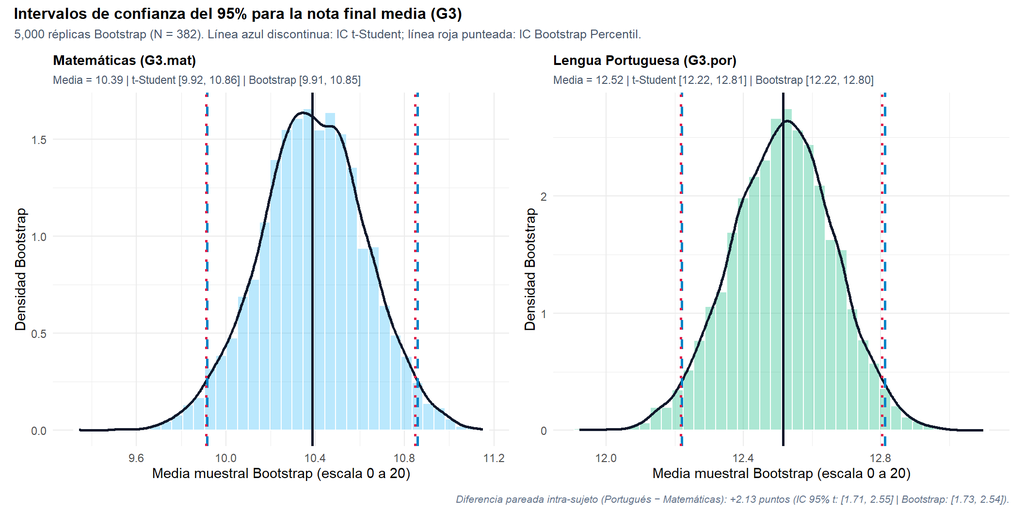

Figure 1: Figura 1. IC 95% (t-Student vs. Bootstrap) para la nota final

```r
plots$means_forest
```

**Hallazgos principales sobre las tres variables:**

1. **Rendimiento académico (`G3.mat` y `G3.por`):**
   - En **Matemáticas**, la media muestral es de **10.39** puntos, con un $\text{IC}_{95\%}$ $t$-Student de **[9.92, 10.86]** y un $\text{IC}_{95\%}$ Bootstrap de **[9.91, 10.85]**.
   - En **Lengua Portuguesa**, la media es sustancialmente superior (**12.52** puntos) y mucho más precisa: su $\text{IC}_{95\%}$ $t$-Student es **[12.22, 12.81]** (semiamplitud de apenas $\pm 0.30$ puntos frente a $\pm 0.47$ en Matemáticas).
   - Al evaluar la **diferencia pareada intra-sujeto** ($d_i = \text{G3}_{\text{por},i} - \text{G3}_{\text{mat},i}$), los estudiantes obtienen en promedio **2.13 puntos más en Portugués que en Matemáticas**, con un $\text{IC}_{95\%}$ $t$ pareado de **[1.71, 2.55]** (Bootstrap: **[1.73, 2.54]**), intervalo que queda completamente por encima de $0$.
2. **Inasistencias escolares (`absences.mat` y `absences.por`):**
   - En **Matemáticas**, el promedio es de **5.32** faltas ($\text{IC}_{95\%}$ $t$: **[4.55, 6.09]**; Bootstrap: **[4.58, 6.10]**).
   - En **Portugués**, el promedio es menor (**3.67** faltas; $\text{IC}_{95\%}$ $t$: **[3.18, 4.17]**; Bootstrap: **[3.19, 4.17]**). Los dos intervalos de asignaturas no se solapan entre sí, confirmando mayor ausentismo medio en Matemáticas.
3. **Consumo de alcohol de fin de semana (`Walc`):**
   - Tratado como índice cuantitativo en escala de 1 a 5, presenta una media de **2.28**, con $\text{IC}_{95\%}$ $t$-Student de **[2.15, 2.41]** y Bootstrap de **[2.15, 2.41]**, ubicando el consumo promedio poblacional entre niveles bajo y moderado.

# 4 Efecto de la asimetría extrema: ¿Cuándo importa usar Bootstrap?

Una pregunta fundamental de la Unidad 3 es por qué los intervalos $t$-Student y Bootstrap resultan tan parecidos en nuestra tabla anterior a pesar de que las inasistencias tienen una asimetría extrema ($4.01$ en Matemáticas, con casos de hasta 75 faltas).

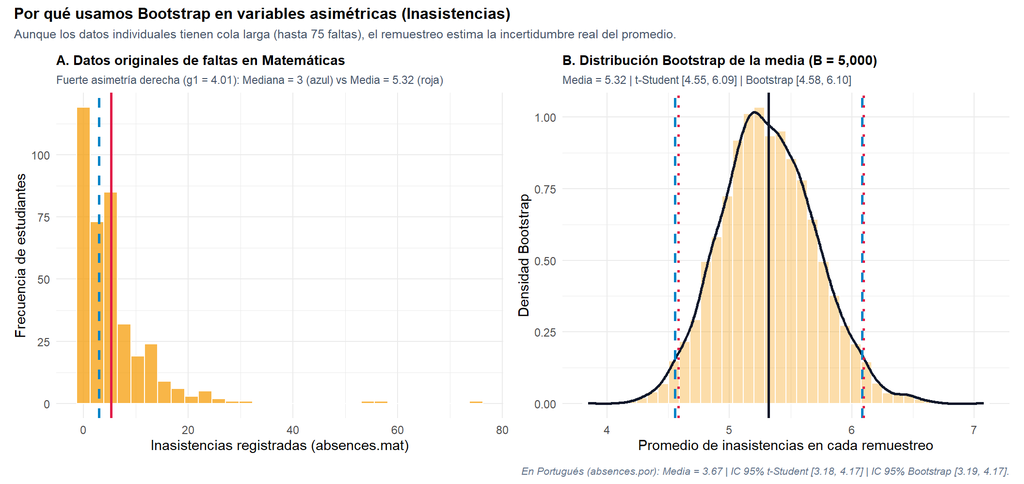

Figure 2: Figura 2. Distribución Bootstrap en inasistencias (B = 5,000)

```r
plots$bootstrap_dist
```

La **Figura 2** ilustra dos fenómenos estadísticos clave:

1. **Acción del Teorema Central del Límite (TCL) con $N = 382$:** Aunque la variable original `absences` es fuertemente asimétrica y discreta, la distribución de la **media muestral** $\bar{X}^*$ en las $5{,}000$ réplicas Bootstrap adopta una forma acampanada muy cercana a la normal teórica. Con $N = 382$, el tamaño muestral amortigua gran parte de la asimetría.
2. **Diferencias mínimas entre ambos intervalos:** En `absences.mat`, el intervalo Bootstrap **[4.584, 6.097]** queda apenas a la derecha del intervalo $t$-Student **[4.552, 6.086]**: el límite inferior pasa de $4.552$ a $4.584$ y el superior de $6.086$ a $6.097$. La dirección es la esperada ante una cola derecha, pero la magnitud es de centésimas, del mismo orden que el error de simulación Monte Carlo de un percentil con $B = 5000$ ($\approx 0.015$). Además, el error estándar es prácticamente idéntico ($0.390$ con $t$ y $0.390$ con Bootstrap). **Conclusión:** con $N = 382$ la asimetría no invalida el intervalo clásico; el Bootstrap funciona como verificación y lo confirma. En muestras pequeñas la aproximación normal es menos fiable y comparar ambos métodos se vuelve más informativo.

# 5 Inferencia de dos muestras: Consumo de alcohol y zona de residencia

En la Unidad 2 observamos diferencias descriptivas entre grupos. Ahora usamos intervalos de confianza del 95% para la **diferencia de medias** ($\mu_1 - \mu_2$) con el fin de determinar si esas brechas se sostienen al inferir hacia la población. Si el intervalo de confianza del 95% para $\mu_1 - \mu_2$ **no incluye el $0$**, existe evidencia estadística al 95% de una diferencia real entre los grupos; si **incluye el $0$**, la diferencia observada es compatible con el azar muestral.

```r
build_contrast_row <- function(label, obj) {
  data.frame(
    Contraste = label,
    Grupo_1 = sprintf("%d (%.2f)", obj$n1, obj$mean1),
    Grupo_2 = sprintf("%d (%.2f)", obj$n2, obj$mean2),
    Diferencia = round(obj$diff, 3),
    IC_Welch_95 = sprintf("[%.3f, %.3f]", obj$welch_low, obj$welch_high),
    IC_Boot_95 = sprintf("[%.3f, %.3f]", obj$boot_low, obj$boot_high),
    Excluye_Cero = ifelse(
      obj$excludes_zero,
      "Sí (Brecha clara)",
      "No (Incierto)"
    )
  )
}

df_contrasts <- rbind(
  build_contrast_row(
    "Alcohol Alto (4-5) - Bajo (1-2): Nota G3 Portugués",
    c_alc$g3_por
  ),
  build_contrast_row(
    "Alcohol Alto (4-5) - Bajo (1-2): Nota G3 Matemáticas",
    c_alc$g3_mat
  ),
  build_contrast_row(
    "Alcohol Alto (4-5) - Bajo (1-2): Faltas Matemáticas",
    c_alc$abs_mat
  ),
  build_contrast_row(
    "Alcohol Alto (4-5) - Bajo (1-2): Faltas Portugués",
    c_alc$abs_por
  ),
  build_contrast_row(
    "Zona Rural - Urbana: Nota G3 Portugués",
    c_addr$g3_por
  ),
  build_contrast_row(
    "Zona Rural - Urbana: Nota G3 Matemáticas",
    c_addr$g3_mat
  )
)

kable(
  df_contrasts,
  col.names = c(
    "Contraste (Grupo 1 - Grupo 2)",
    "n1 (Media 1)", "n2 (Media 2)", "Dif. (G1 - G2)",
    "IC 95% Welch", "IC 95% Bootstrap", "¿Excluye el 0?"
  ),
  caption = paste(
    "Tabla 2. Intervalos de confianza del 95% (Welch y Bootstrap) para",
    "diferencias de medias por consumo de alcohol y zona de residencia."
  )
)
```

Table 2: Tabla 2. Intervalos de confianza del 95% (Welch y Bootstrap) para diferencias de medias por consumo de alcohol y zona de residencia.

| Contraste (Grupo 1 - Grupo 2) | n1 (Media 1) | n2 (Media 2) | Dif. (G1 - G2) | IC 95% Welch | IC 95% Bootstrap | ¿Excluye el 0? |
| --- | --- | --- | --- | --- | --- | --- |
| Alcohol Alto (4-5) - Bajo (1-2): Nota G3 Portugués | 76 (11.30) | 230 (12.97) | -1.663 | [-2.454, -0.871] | [-2.441, -0.893] | Sí (Brecha clara) |
| Alcohol Alto (4-5) - Bajo (1-2): Nota G3 Matemáticas | 75 (9.97) | 231 (10.40) | -0.425 | [-1.503, 0.654] | [-1.474, 0.620] | No (Incierto) |
| Alcohol Alto (4-5) - Bajo (1-2): Faltas Matemáticas | 75 (8.28) | 231 (3.99) | 4.289 | [2.035, 6.543] | [2.158, 6.560] | Sí (Brecha clara) |
| Alcohol Alto (4-5) - Bajo (1-2): Faltas Portugués | 76 (5.07) | 230 (3.24) | 1.822 | [0.469, 3.176] | [0.485, 3.172] | Sí (Brecha clara) |
| Zona Rural - Urbana: Nota G3 Portugués | 81 (11.44) | 301 (12.80) | -1.360 | [-2.209, -0.510] | [-2.218, -0.537] | Sí (Brecha clara) |
| Zona Rural - Urbana: Nota G3 Matemáticas | 81 (9.56) | 301 (10.61) | -1.056 | [-2.194, 0.083] | [-2.196, 0.071] | No (Incierto) |

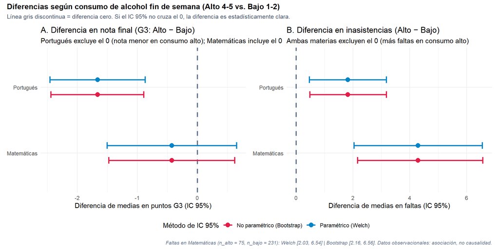

Figure 3: Figura 3. IC 95% para diferencias de medias por consumo de alcohol

```r
plots$contrasts
```

**Interpretación de los contrastes de dos muestras:**

- **Consumo de alcohol y calificaciones (`G3`):**
  - En **Portugués**, los estudiantes con consumo de alcohol alto (`Walc` 4–5, $n = 76$) tienen en promedio **1.66 puntos menos** que quienes reportan consumo bajo (`Walc` 1–2, $n = 230$). Tanto el intervalo de Welch (**[-2.45, -0.87]**) como el Bootstrap (**[-2.44, -0.89]**) quedan íntegramente por debajo de cero: **la brecha negativa es estadísticamente clara**.
  - En **Matemáticas**, en cambio, la diferencia puntual es de apenas **-0.42 puntos** y su intervalo del 95% (**[-1.50, 0.65]**) cruza ampliamente el cero. Por tanto, **no hay evidencia estadística** de una diferencia de medias en la nota de Matemáticas entre ambos grupos de consumo.
- **Consumo de alcohol e inasistencias (`absences`):**
  - Aquí se revela un hallazgo clave al integrar la tercera variable: aunque en Matemáticas la nota media no mostraba diferencia concluyente por alcohol, las **inasistencias sí son mayores en el grupo de consumo alto**. Quienes tienen consumo alto registran **4.29 faltas más en Matemáticas** (Welch: **[2.03, 6.54]**; Bootstrap: **[2.16, 6.56]**) y **1.82 faltas más en Portugués** (Welch: **[0.47, 3.18]**). Welch y Bootstrap llegan a la misma conclusión en ambas materias, aun con un grupo de consumo alto de solo $n_1 = 75$.
- **Brecha Urbano–Rural (`address`):**
  - En **Portugués**, los estudiantes rurales ($n = 81$) obtienen en promedio **1.36 puntos menos** que los urbanos ($n = 301$), con un $\text{IC}_{95\%}$ de Welch de **[-2.21, -0.51]** que excluye el cero.
  - En **Matemáticas**, la diferencia de **-1.06 puntos** presenta un $\text{IC}_{95\%}$ de Welch de **[-2.19, 0.08]**, que roza e incluye ligeramente el cero, por lo que la evidencia es limítrofe.

# 6 Inferencia sobre proporciones de aprobación y razón de varianzas

Para completar todos los escenarios de inferencia de la Unidad 3 (proporciones poblacionales, diferencia de proporciones y cociente de varianzas), analizamos la tasa de aprobación ($G3 \ge 10$ sobre 20) y la dispersión relativa entre asignaturas.

```r
df_prop <- data.frame(
  Parametro = c(
    "Proporción aprobación Matemáticas (G3 >= 10)",
    "Proporción aprobación Portugués (G3 >= 10)",
    "Diferencia de proporciones pareada (Matemáticas - Portugués)",
    "Razón de varianzas en notas (Var Mat / Var Por)",
    "Razón de varianzas en faltas (Var Mat / Var Por)"
  ),
  Estimacion = c(
    pct(pr$pass_mat$prop, 1),
    pct(pr$pass_por$prop, 1),
    paste0(fmt_num(100 * pr$diff_pass$diff, 1), " pp"),
    fmt_num(vr$g3$ratio, 2),
    fmt_num(vr$absences$ratio, 2)
  ),
  IC_Principal_95 = c(
    sprintf(
      "[%.1f%%, %.1f%%] (Wald)",
      100 * pr$pass_mat$wald_low,
      100 * pr$pass_mat$wald_high
    ),
    sprintf(
      "[%.1f%%, %.1f%%] (Wald)",
      100 * pr$pass_por$wald_low,
      100 * pr$pass_por$wald_high
    ),
    sprintf(
      "[%.1f, %.1f] pp (Wald pareado)",
      100 * pr$diff_pass$ci_low,
      100 * pr$diff_pass$ci_high
    ),
    sprintf(
      "[%.2f, %.2f] (Bootstrap pareado)",
      vr$g3$ci_low,
      vr$g3$ci_high
    ),
    sprintf(
      "[%.2f, %.2f] (Bootstrap pareado)",
      vr$absences$ci_low,
      vr$absences$ci_high
    )
  ),
  IC_Alternativo_95 = c(
    sprintf(
      "[%.1f%%, %.1f%%] (Wilson)",
      100 * pr$pass_mat$wilson_low,
      100 * pr$pass_mat$wilson_high
    ),
    sprintf(
      "[%.1f%%, %.1f%%] (Wilson)",
      100 * pr$pass_por$wilson_low,
      100 * pr$pass_por$wilson_high
    ),
    sprintf(
      "Excluye 0 (%d aprueban solo Por. vs. %d solo Mat.)",
      pr$diff_pass$n01, pr$diff_pass$n10
    ),
    "Excluye 1 (mayor dispersión en Mat.)",
    "Excluye 1 (mayor dispersión en Mat.)"
  )
)

kable(
  df_prop,
  col.names = c(
    "Parámetro Poblacional", "Estimación Puntual",
    "IC 95% Clásico", "IC 95% Alternativo / Interpretación"
  ),
  caption = paste(
    "Tabla 3. Intervalos de confianza del 95% para proporciones de aprobación",
    "(Wald y Wilson), diferencia pareada de proporciones y razón de",
    "varianzas (Bootstrap pareado: mismos estudiantes en ambas materias)."
  )
)
```

Table 3: Tabla 3. Intervalos de confianza del 95% para proporciones de aprobación (Wald y Wilson), diferencia pareada de proporciones y razón de varianzas (Bootstrap pareado: mismos estudiantes en ambas materias).

| Parámetro Poblacional | Estimación Puntual | IC 95% Clásico | IC 95% Alternativo / Interpretación |
| --- | --- | --- | --- |
| Proporción aprobación Matemáticas (G3 >= 10) | 66.8% | [62.0%, 71.5%] (Wald) | [61.9%, 71.3%] (Wilson) |
| Proporción aprobación Portugués (G3 >= 10) | 91.6% | [88.8%, 94.4%] (Wald) | [88.4%, 94.0%] (Wilson) |
| Diferencia de proporciones pareada (Matemáticas - Portugués) | -24.9 pp | [-29.7, -20.0] pp (Wald pareado) | Excluye 0 (104 aprueban solo Por. vs. 9 solo Mat.) |
| Razón de varianzas en notas (Var Mat / Var Por) | 2.53 | [1.96, 3.28] (Bootstrap pareado) | Excluye 1 (mayor dispersión en Mat.) |
| Razón de varianzas en faltas (Var Mat / Var Por) | 2.42 | [1.42, 3.87] (Bootstrap pareado) | Excluye 1 (mayor dispersión en Mat.) |

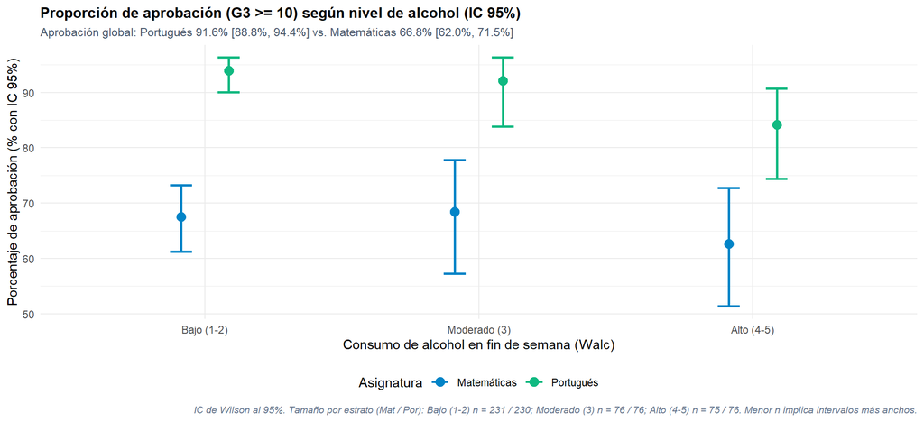

Figure 4: Figura 4. Proporción de aprobación (G3 >= 10) con IC 95%

```r
plots$proportions
```

- **Aprobación académica ($p$ y $p_{\text{mat}} - p_{\text{por}}$):** Mientras que en Lengua Portuguesa aprueba el **91.6%** de la cohorte (350 de 382; $\text{IC}_{95\%}$ Wald: **88.8% a 94.4%**), en Matemáticas aprueba el **66.8%** (255 de 382; $\text{IC}_{95\%}$ Wald: **62.0% a 71.5%**). La diferencia de proporciones es de **-24.9 puntos porcentuales**, con un $\text{IC}_{95\%}$ de **[-29.7, -20.0] pp**. Como son los **mismos estudiantes** en ambas materias, el intervalo es **pareado**: su varianza depende de los casos discordantes (104 aprueban solo Portugués y 9 solo Matemáticas), no de dos muestras independientes.
- **Razón de varianzas ($\sigma^2_{\text{mat}} / \sigma^2_{\text{por}}$):** El cociente de varianzas en las calificaciones finales es de **2.53**. El intervalo clásico $F$ de Snedecor no es adecuado aquí: supone muestras **independientes** y **normales**, y en cambio las notas son pareadas (mismos estudiantes) y `G3.mat` no es normal. Por eso usamos un **Bootstrap pareado** (remuestreando estudiantes completos), que da un $\text{IC}_{95\%}$ de **[1.96, 3.28]** (el $F$ habría dado un intervalo más estrecho, [2.07, 3.10]). El intervalo excluye el $1$: la varianza de Matemáticas es mayor, unas 2.5 veces la de Portugués, aunque los datos no permiten afirmar con 95% de confianza que sea más del doble. Esa mayor dispersión explica por qué los intervalos de Matemáticas son más anchos.